# The effects of Cyanobacteria on quantity, quality, and timing of insect emergence.

# 1 Overview of the project

This document illustrates how I use R, Quarto and interactive tools to organise research projects and develop reproducible workflows. It integrates scientific rationale, experimental design, quantitative calculations, protocols, data management and references into a single, interconnected environment. Shared parameters and automated calculations help minimise manual data entry and inconsistencies across project components. The document is an example of my approach to research organisation and documentation; some experimental details reflect an earlier stage of project development.

## 1.1 🔬 What’s this project about?

In one sentence: **we’re trying to understand how cyanobacteria affect the connection between aquatic and terrestrial ecosystems.**

Here’s the longer version:

Freshwater ecosystems, such as ponds, aren’t isolated from the land around them — they’re constantly exchanging resources with it. One of the most significant links is **emerging aquatic insects**: insects that spend their larval life underwater and then emerge as adults, flying out of the water and into terrestrial systems. When they emerge, they become food for spiders, birds, bats, and all sorts of land-based predators. In many ecosystems, this pulse of insects is a huge — and often irreplaceable — source of energy and nutrients (e.g., Omega-3) for terrestrial food webs. Cut off that pulse, make it low quality, or shift when it happens, and you can ripple effects all the way up terrestrial food webs.

Now bring in **cyanobacteria** (aka “blue-green algae”). Cyanobacterial blooms are becoming more common worldwide due to warming and nutrient pollution, and they can mess with aquatic food webs in (at least) two very different ways:

1. **Toxins** — many cyanobacteria produce toxins (like microcystins) that can directly harm the animals living in the water.
2. **Poor food quality** — even when they’re not toxic, cyanobacteria tend to be nutritionally poor food (they lack certain essential fatty acids and other nutrients that animals need to grow and reproduce).

The tricky part: these two effects usually happen *at the same time* in nature, so it’s really hard to know which one is actually driving the damage. Is it the toxic, or is it the poor quality food effect (or both)? **Teasing these two mechanisms apart is the central goal of this project.**

## 1.2 🧪 Why *Chaoborus sp* and *Ischnura elegans*?

To study this, we use *Chaoborus* (phantom midge) and *Ischnura elegans* (blue-tailed damselfly) as our model organisms. A few reasons they are a great fit:

- They are **widespread**, found in lakes and ponds, so what we learn has broad relevance.
- They are well-established models in freshwater ecology, so there’s a solid foundation of methods and knowledge to build on, and it’s (relatively) easy to keep in the lab.

By feeding *Chaoborus sp* and *Ischnura elegans* different cyanobacterial diets (toxic vs. non-toxic, nutritionally varied) and tracking how they grow, survive, and eventually emerge, we can start to disentangle *toxicity* from *food quality* — and understand what that means for the animals waiting on land for their next meal to fly out of the water.

Thanks for stopping by — happy reading, and welcome aboard! 🔬🦟

## 1.3 👥 Who’s in this?

This project is powered by a small but very dedicated crew:

| Name | Role | Institution |
| --- | --- | --- |
| Emanuele Giacomuzzo | Creator of this project, postdoc | University of Copenhagen, DK |
| Jana Isanta-Navarro | Professor | University of Copenhagen, DK |
| Kirsten Seestern | Professor | University of Copenhagen, DK |
| Ali Ger | Professor | Federal University of Rio Grande do Norte, Brazil |
| Irma Carvalho | Postdoc | Federal University of Rio Grande do Norte, Brazil |
| Mikael Kosmou | MSc student, writing his MSc thesis on this project | University of Copenhagen, DK |
| Tobias Hoffmann Jensen | BSc student, wrote his BSc thesis on this project | University of Copenhagen, DK |
| Tina Katherine Varis | BSc student, doing research assistanship within this project | Elon University, USA, exchange @ University of Copenhagen, DK |

Basically, a small international team spanning Denmark, Brazil, and the US, at every career stage from BSc to PI — all digging into the same big question 🌍

Here I import all the packages from my library.

**Note📖 Library**

**Show calculation code**

```r
library(tidyverse)
```

**Show calculation code**

```r
library(here)
```

# 2 Parameters & calculations

**NoteParameters**

**Show calculation code**

```r
# DW = dry weight

# ─────────────────────────────────────────────
# 🌐 General
# ─────────────────────────────────────────────

Treatments <- 4
Replicates <- 4

# ─────────────────────────────────────────────
# 🪜 Infrastructure
# ─────────────────────────────────────────────

Shelves <- 16
Max_weight_per_shelf_kg <- 20

Small_jar_liquid_litres <- 0.08
Small_jar_with_liquid_kg <- 0.2

Large_jar_liquid_litres <- 0.8
Large_jar_with_liquid_kg <- 1.5
Large_jar_diameter_cm <- 9

bucket_liquid_litres <- 8

# ─────────────────────────────────────────────
# 🔥 Autoclaving
# ─────────────────────────────────────────────

Autoclave_temperature_C <- 121 # Vana & Claudia defined this, as it's written on the autoclave at the Marine Biology Section, but I'm not sure where they got this from
Autoclave_solids_minutes <- 25 # Vana & Claudia defined this, as it's written on the autoclave at the Marine Biology Section, but I'm not sure where they got this from
Autoclave_1L_liquids_minutes <- 45 # Vana & Claudia defined this, as it's written on the autoclave at the Marine Biology Section, but I'm not sure where they got this from
Autoclave_2L_liquids_minutes <- 60 # I always autoclaved COMBO in 2L bottles for this amount of time and never had a problem with it
Autoclave_5L_liquids_minutes <- 85 # Vana & Claudia defined this, as it's written on the autoclave at the Marine Biology Section, but I'm not sure where they got this from

# ─────────────────────────────────────────────
# 🦟 Chaoborus / Ischnura
# ─────────────────────────────────────────────

# Weight

Chaoborus_third_instar_DW_mg <- 0.79 # Lowest weight in the following paper: Parma, S. (1971). Chaoborus flavicans (Meigen)(Diptera, Chaoboridae): an autecological study.
Ischnura_small_adult_DW_mg <- NA_real_  # TBD
Ischnura_large_adult_DW_mg <- NA_real_  # TBD

# Survival

Chaoborus_dead_to_alive_ratio_worst_treatment <- 2
Ischnura_dead_to_alive_ratio_worst_treatment <- NA_real_  # TBD

# Feeding

N_days_per_feeding_event <- 2

Chaoborus_Daphnia_neonates_eaten_per_day <- 20 #Based on female fourth instar eating 1.25 mm D. magna babies (Büns & Ratte, 1991)
Chaoborus_Daphnia_neonates_eaten_max_recorded <- 25 # Highest single-feeding count observed
Chaoborus_Daphnia_neonates_eaten_max_mm <- NA_real_  # TBD
Chaoborus_Daphnia_neonates_eaten_max_age_days <- 5 # Oldest a Daphnia neonate can be while still small enough for Chaoborus to eat according to the feeding experiment with Tobias.

Ischnura_Daphnia_neonates_eaten_per_day <- NA_real_  # TBD
Ischnura_Daphnia_neonates_eaten_max_recorded <- NA_real_  # TBD
Ischnura_Daphnia_neonates_eaten_max_mm <- NA_real_  # TBD
Ischnura_Daphnia_neonates_eaten_max_age_days <- NA_real_  # TBD

# Individuals per jar

Chaoborus_larvae_per_jar <- 10 # Initial density, within the upper range of natural peak densities (Xie et al., 1998)
Ischnura_larvae_per_jar <- NA_real_  # TBD



# ─────────────────────────────────────────────
# 🦐 Daphnia
# ─────────────────────────────────────────────

# Weight

Daphnia_adult_DW_mg <- 0.18 # Average weight of an individual in the following paper: Simčič, T., & Brancelj, A. (1997). Electron transport system (ETS) activity and respiration rate in five Daphnia species at different temperatures. Hydrobiologia, 360(1), 117-125.

# Reproduction

Daphnia_offsprings_per_mother_per_5_days <- 20

# Feeding

Daphnia_algae_C_ad_libitum_mg_per_L_per_day <- 2 # This is the amount of carbon that Daphnia magna can consume per day at ad libitum feeding conditions, based on the following paper: Lampert, W. (1978). The experimental analysis of food limitation in Daphnia. I. The search for a control mechanism. Oecologia, 37(1), 1-19.

# Experiment

Daphnia_cohorts_adults_per_jar <- 15 # Suggested by Jana, as in her experience it's the highest density of Daphnia in the jars that doesn't stress them out too much.
Daphnia_adults_per_new_cohort_bucket <- 80 # Individuals pipetted from stock into each newly created cohort bucket (protocol/3_create_Daphnia.md)
Daphnia_cohorts_in_rotation <- 3
Daphnia_jars_per_cohort <- 3

# ─────────────────────────────────────────────
# 🧪 Phytoplankton
# ─────────────────────────────────────────────

# General

Phyto_species_count <- 4 # M. aeruginosa, S. elongatus, N. limnetica, T. obliquus
Phyto_low_quality_food_ratio <- 0.5 # Food ratio of Microcystis aeruginosa or Synechococcus elongatus. Feeding Daphnia magna with 50% of Microcystis can keep cultures dense enough to perform experiment (Macke et al., 2017) but still have a negative effect (Schwarzenberger et al., 2012, 2013). Feeding Daphnia magna with 50% of Synechococcus can also keep cultures alive but still have a negative effect (Demott & Müller-Navarra, 1997).
Phyto_vessels_per_species <- 2

# Stock flasks

Phyto_stock_flask_capacity_mL <- 100
Phyto_stock_flask_liquid_mL <- 50
Phyto_stock_flask_inoculation_mL <- 30
Phyto_stock_flask_inoculation_interval_days <- 28

# Stock bottles

Phyto_stock_bottle_capacity_mL <- 500
Phyto_stock_bottle_liquid_mL <- 300
Phyto_stock_bottle_inoculation_mL <- 200
Phyto_stock_bottle_inoculation_interval_days <- 7

# Experimental bottles

Phyto_experimental_bottle_capacity_mL <- 2000
Phyto_experimental_bottle_liquid_mL <- 2000
Phyto_experimental_bottle_inoculation_mL <- 200
Phyto_experimental_bottle_usability_days <- 10 # The number of days the  experimental bottles stay in the exponential phase. 10 comes from Ema and Jana's experience.
Phyto_experimental_bottle_highest_mg_C_per_L <- 50 #M. aeruginosa is the one that grows the worst and that in Thostrup & Christophersen, 1999 grew up to 150, we use 50 to be conservative. Also, Vana told me that her T. obliquus grows at 28-150 mg C / L
Phyto_experimental_bottle_inoculation_interval_days <- 7

# COMBO medium

COMBO_batch_volume_litres <- 20
COMBO_days_in_advance <- 1 #Needs one day to be autoclaved

# Optical density to carbon calibration curves

# OD-to-carbon calibration curves (mg C/L = slope x OD_480 - intercept), fitted per species from a
# dilution series read on the spectrophotometer and filtered onto pre-combusted GF/C filters for
# carbon analysis (method: protocol/quarto/22_2026_03_27_OD_curve_Microcystis.md); used by
# calculations/food_calculator.qmd to dose Daphnia feeding (see 6_experimental_procedure.qmd)
# This comes from Varvara Paida's calibration work.

Tetradesmus_OD_to_C_slope <- 158.32
Tetradesmus_OD_to_C_intercept <- -10.991
Synechococcus_OD_to_C_slope <- 89.419
Synechococcus_OD_to_C_intercept <- -4.463
extra_food_ratio <- 0.25 # Extra food to make just in case

# ─────────────────────────────────────────────
# 🍽️ Diet treatments
# ─────────────────────────────────────────────

# Daphnia raised on each mix before being fed to Chaoborus (Figure 1)

Diet_names <- c("Low-quality toxic", "Low-quality", "High-quality", "High-quality (toxin-spiked)")

# Fraction of each species by carbon in the Daphnia diet for each treatment above, in the same order.
# The 4th treatment's toxin exposure comes from lysed M. aeruginosa dosed directly into the Chaoborus
# jar (Figure 1), not through the Daphnia diet, so it adds no Microcystis to the fractions below — see
# the To do in 4_calculations.qmd about sizing that dose.
Diet_Microcystis_fraction     <- c(Phyto_low_quality_food_ratio, 0, 0, 0)
Diet_Synechococcus_fraction   <- c(0, Phyto_low_quality_food_ratio, 0, 0)
Diet_Nannochloropsis_fraction <- c(0, 0, 1, 1)
Diet_Tetradesmus_fraction     <- c(1 - Phyto_low_quality_food_ratio, 1 - Phyto_low_quality_food_ratio, 0, 0)

# ─────────────────────────────────────────────
# ☠️ Toxins
# ─────────────────────────────────────────────

# Microcystin production

Microcystins_mg_per_g_DW_phytoplankton <- 1 # In *Microcystis aeruginosa* (strain PCC 7806, grown in N-limited modified MLA medium) depending on growth phase. See Long, B. M., Jones, G. J., & Orr, P. T. (2001). Cellular microcystin content in N-limited Microcystis aeruginosa can be predicted from growth rate. Applied and Environmental Microbiology, 67(1), 278-283.

# Microcystin biodilution

Microcystins_biodilution_factor_Daphnia <- 80 # *Daphnia magna* shows roughly 80-fold biodilution relative to *M. aeruginosa* — about 2 mg g⁻¹ DW in the phytoplankton versus ~0.025 mg g⁻¹ DW in *D. magna* [@thostrup1999].
Microcystins_biodilution_factor_Chaoborus <- 5 # Based on a field study where toxins were detected with HPLC/PDA: Sotton, B., Guillard, J., Anneville, O., Maréchal, M., Savichtcheva, O., & Domaizon, I. (2014). Trophic transfer of microcystins through the lake pelagic food web: Evidence for the role of zooplankton as a vector in fish contamination. Science of the Total Environment, 466, 152-163. However, the literature reports also total biodilution. @lauren-maatta1995 found no detectable microcystins in *Chaoborus* fed Microcystis-exposed *Daphnia*, though they used HPLC (a comparatively high detection limit) and did not measure toxins in the *Daphnia* themselves; @sotton2014, a field study using HPLC/PDA, found roughly 5-fold biodilution from zooplankton (863 ng g⁻¹ FW) to *Chaoborus* (168 ng g⁻¹ FW); and @riehle2024, using high-resolution LC–MS/MS, detected microcystins in zooplankton (2.5–4.5 µg g⁻¹ DW) but not in *Chaoborus*.

# Microcystin analysis

Microcystins_detection_limit_ug_per_L <- 0.05 # Eurofins Microcystin Plate Kit detects down to 0.05 µg L⁻¹, the Abraxis Microcystins-ADDA ELISA Kit and the Beacon Microcystin ELISA Kit both detect down to 0.10 µg L⁻¹, and the Envirologix Microcystins Quantiplate Kit detects down to 0.15 µg L⁻¹.
Microcystins_extraction_volume_mL <- 1 # Placeholder — volume each freeze-dried Chaoborus sample will be extracted/reconstituted into before running the ELISA; not yet decided, so confirm against the chosen kit's protocol and update (see To do below).

# ─────────────────────────────────────────────
# ⚖️ DW needed for analyses
# ─────────────────────────────────────────────

DW_needed_for_PUFAs_mg <- 1 # Tarn Preet Parmar, personal communication
DW_needed_for_sterols_mg <- 1 # Tarn Preet Parmar, personal communication
DW_needed_for_N_and_C_mg <- 1.5 # Dominik Martin-Creuzburg, personal communication
DW_needed_for_P_mg <- NA # The lowest Claudia recorded was 0.005 mg of phosphorus (but she doesn’t know for how much dry weight).
DW_needed_for_toxins_mg <- NA
```

**NoteCalculations – 🧪 OD**

## 2.1 Purpose

We need to provide the same amount of carbon to Daphnia otherwise a diet could simply be supplying more or less food overall, confounding food *quantity* with the food *quality*. Optical density (OD) at 480 nm is a fast proxy for how much algal carbon is in a culture, but the relationship between OD and carbon content is species-specific and must be calibrated for each algal species.

This analysis fits that calibration for *Microcystis aeruginosa* and *Nannochloropsis limnetica*: a linear equation converting an OD<sub>480</sub> reading of either species, grown in zoo-COMBO medium, into the corresponding carbon concentration (mg C/L). Once fitted, the equation lets the volume of culture needed for a given carbon dose be read straight off a quick OD measurement.

## 2.2 Methods

### 2.2.1 Dilution series and optical density

For each species, a dilution series was prepared in zoo-COMBO medium (COMBO without nitrogen and phosphorus, which halts algal growth) — *Microcystis aeruginosa* at 0, 10, 25, 35, 50, 75, and 100% of the stock culture, and *Nannochloropsis limnetica* at 0, 10, 25, 50, 75, and 100%. Each dilution’s OD<sub>480</sub> was read on a spectrophotometer (raw data in 2_data/01_unprocessed/01_OD).

### 2.2.2 Carbon content

A matched volume of each dilution was filtered onto a drying plate — one plate per species — dried in a 24-well plate, both species packaged together in a 96-well plate and sent together to Dominik Martin-Creuzburg’s lab (Bad Saarow, Germany) for carbon and nitrogen analysis. Data came back with filters from an unrelated project (Claudia’s), which are excluded. Filters flagged as compromised — accidentally touched during handling, burnt during analysis, or lost — are excluded as well.

### 2.2.3 Calibration

Carbon mass is converted to a concentration (mg C/L) by dividing the measured carbon (mg) by the volume of culture filtered (mL). That concentration is then regressed linearly against the matching OD<sub>480</sub> reading, separately for each species:

$$C_{mg/L} = \text{intercept} + \text{slope} \times OD_{480}$$

**Show calculation code**

```r
library(tidyverse)

OD_data_dir <- "../2_data/01_unprocessed/01_OD"

# ----- Microcystis aeruginosa: OD + volume ------ #

Microcystis_volume_added <- read.csv(file.path(OD_data_dir, "Microcystis_volume.csv"), fileEncoding = "UTF-8-BOM")
Microcystis_OD <- read.csv(file.path(OD_data_dir, "Microcystis_OD.csv"), fileEncoding = "UTF-8-BOM")

Microcystis_volume_and_OD <- left_join(
  Microcystis_volume_added,
  Microcystis_OD,
  by = c("species", "medium", "percentage")
) %>%
select(-c("comment", "position_drying_plate"))

# ----- Nannochloropsis limnetica: OD + volume ------ #

Nannochloropsis_volume_added <- read.csv(file.path(OD_data_dir, "Nannochloropsis_volume.csv"), fileEncoding = "UTF-8-BOM") %>%
mutate(problem = "no")
Nannochloropsis_OD <- read.csv(file.path(OD_data_dir, "Nannochloropsis_OD.csv"), fileEncoding = "UTF-8-BOM")

Nannochloropsis_volume_and_OD <- left_join(
  Nannochloropsis_volume_added,
  Nannochloropsis_OD,
  by = c("species", "medium", "percentage")
) %>%
select(-c("position_drying_plate"))

# ----- Carbon content ------ #
# "plate" holds the elemental-analyser plate label. Rows from the unrelated
# project were run on plate "Claudia" and are dropped here so only this
# calibration's samples remain.

Microcystis_Nannochlaropsis_C <- read.csv(file.path(OD_data_dir, "Microcystis_Nannochlaropsis_C.csv"), fileEncoding = "UTF-8-BOM") %>%
filter(!plate == "Claudia") %>%
select(position_C_analysis_plate = plate, C_mg = C..mg.) %>%
mutate(
  position_C_analysis_plate = str_extract(str_trim(position_C_analysis_plate), "^[A-Z]\\d+"),
  C_mg = suppressWarnings(as.numeric(C_mg)) # non-numeric placeholders (e.g. "sample lost") become NA
)

# ----- Merge tables ------ #
# problem != "no" rows (a touched or burnt filter) and unmatched/NA carbon
# readings are dropped, since neither gives a usable calibration point.

Volume_and_OD <- bind_rows(Microcystis_volume_and_OD, Nannochloropsis_volume_and_OD)

Volume_OD_and_C <- left_join(
  Volume_and_OD,
  Microcystis_Nannochlaropsis_C,
  by = "position_C_analysis_plate"
) %>%
filter(!is.na(C_mg), problem != "yes") %>%
select(species, percentage, volume_added_ml, OD_480_nm, C_mg)
```

**Show calculation code**

```r
species_OD_C <- Volume_OD_and_C %>%
mutate(C_mg_per_L = C_mg / volume_added_ml * 1000) %>%
select(species, OD_480_nm, C_mg_per_L)
```

## 2.3 Results

### 2.3.1 Microcystis aeruginosa

**Show calculation code**

```r
m_aeruginosa_OD_C <- species_OD_C %>%
filter(species == "microcystis_aeruginosa")

m_aeruginosa_lm <- lm(C_mg_per_L ~ OD_480_nm, data = m_aeruginosa_OD_C)
m_aeruginosa_intercept <- coef(m_aeruginosa_lm)[["(Intercept)"]]
m_aeruginosa_slope <- coef(m_aeruginosa_lm)[["OD_480_nm"]]
m_aeruginosa_r_squared <- summary(m_aeruginosa_lm)$r.squared

cat(sprintf(
  "Microcystis aeruginosa: C_mg_per_L = %.2f + %.2f * OD_480_nm (R2 = %.3f)\n",
  m_aeruginosa_intercept, m_aeruginosa_slope, m_aeruginosa_r_squared
))
```

```
Microcystis aeruginosa: C_mg_per_L = -0.41 + 120.15 * OD_480_nm (R2 = 0.998)
```

**Show calculation code**

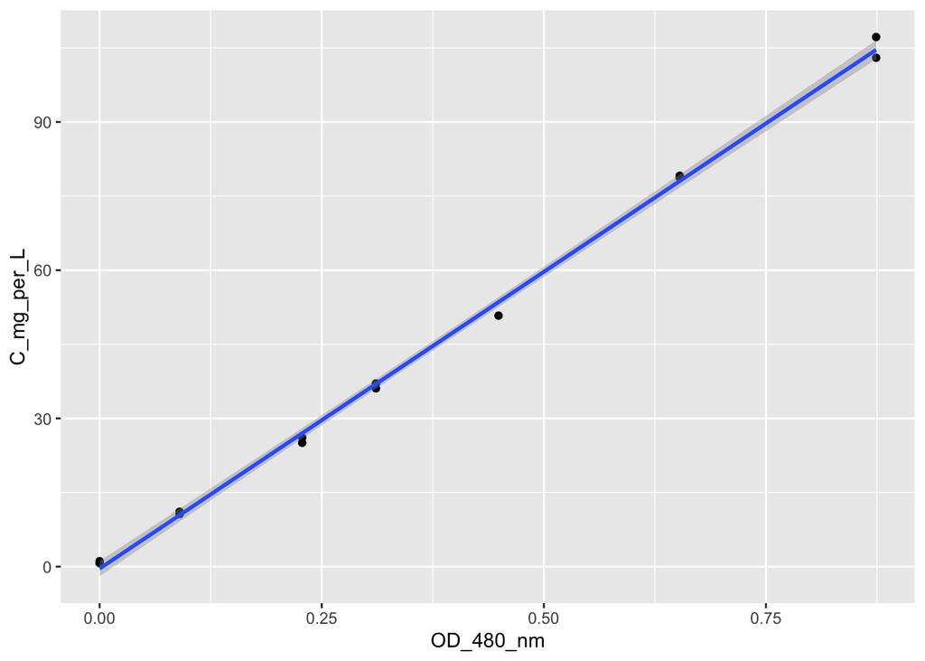

```r
ggplot(aes(x = OD_480_nm, y = C_mg_per_L), data = m_aeruginosa_OD_C) +
geom_point() +
geom_smooth(method = "lm", formula = y ~ x)
```

### 2.3.2 Nannochloropsis limnetica

**Show calculation code**

```r
n_limnetica_OD_C <- species_OD_C %>%
filter(species == "nannochloropsis_limnetica")

n_limnetica_lm <- lm(C_mg_per_L ~ OD_480_nm, data = n_limnetica_OD_C)
n_limnetica_intercept <- coef(n_limnetica_lm)[["(Intercept)"]]
n_limnetica_slope <- coef(n_limnetica_lm)[["OD_480_nm"]]
n_limnetica_r_squared <- summary(n_limnetica_lm)$r.squared

cat(sprintf(
  "Nannochloropsis limnetica: C_mg_per_L = %.2f + %.2f * OD_480_nm (R2 = %.3f)\n",
  n_limnetica_intercept, n_limnetica_slope, n_limnetica_r_squared
))
```

```
Nannochloropsis limnetica: C_mg_per_L = 0.43 + 96.73 * OD_480_nm (R2 = 0.991)
```

**Show calculation code**

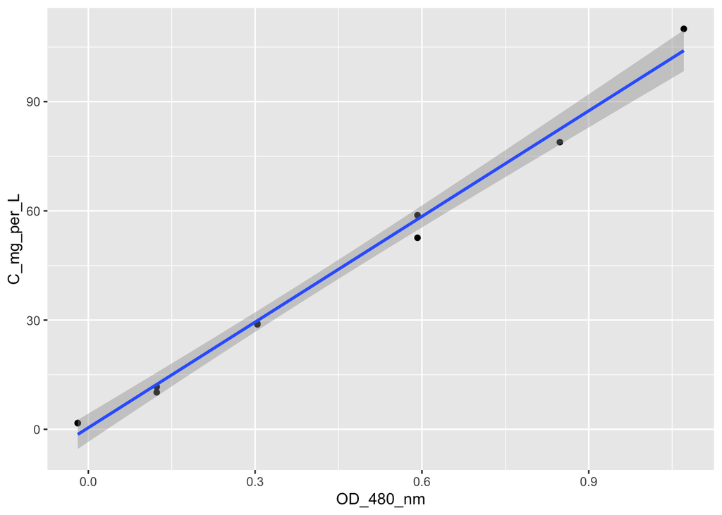

```r
ggplot(aes(x = OD_480_nm, y = C_mg_per_L), data = n_limnetica_OD_C) +
geom_point() +
geom_smooth(method = "lm", formula = y ~ x)
```

## 2.4 Use

These two equations are what let a single OD<sub>480</sub> reading of a treatment’s phytoplankton culture be converted, on any given feeding day, into a volume of that culture to add so that every diet receives the same carbon dose. Holding food quantity constant this way is what lets differences in *Daphnia* and *Chaoborus* performance across treatments be attributed to food quality and toxin exposure, rather than to how much food they were fed.

## 2.5 Save parameters

**Show calculation code**

```r
Nannochloropsis_OD_to_C_slope <- round(n_limnetica_slope, 2)
Nannochloropsis_OD_to_C_intercept <- round(n_limnetica_intercept, 2)
Microcystis_OD_to_C_slope <- round(m_aeruginosa_slope, 2)
Microcystis_OD_to_C_intercept <- round(m_aeruginosa_intercept, 2)
```

calculations/food_calculator.qmd embeds a standalone Shinylive app that runs client-side in the reader’s browser, with no access to this R session or to the repository’s data files at render time. The snapshot below is how it stays in sync with the calibration above without values being copied over by hand: re-rendering this file (or the master document) refreshes the snapshot, and re-rendering food_calculator.qmd then bakes the refreshed numbers into the embedded app.

**Show calculation code**

```r
## Diet_*_fraction (source of truth for diet composition, see 4_parameters.qmd) are
## vectors, so every value is deparsed to an R literal (e.g. "c(0.5, 0, 0, 0)") and the
## whole value column is stored as text; food_calculator.qmd splices these literals
## straight into the app's R source, so a scalar's deparsed text ("0.8") assigns the
## same way a vector's ("c(0.5, 0, 0, 0)") does.
Food_calculator_parameters <- data.frame(
  name = c(
    "Large_jar_liquid_litres",
    "Daphnia_algae_C_ad_libitum_mg_per_L_per_day",
    "N_days_per_feeding_event",
    "extra_food_ratio",
    "Diet_Microcystis_fraction",
    "Diet_Synechococcus_fraction",
    "Diet_Nannochloropsis_fraction",
    "Diet_Tetradesmus_fraction",
    "Tetradesmus_OD_to_C_slope",
    "Tetradesmus_OD_to_C_intercept",
    "Synechococcus_OD_to_C_slope",
    "Synechococcus_OD_to_C_intercept",
    "Microcystis_OD_to_C_slope",
    "Microcystis_OD_to_C_intercept",
    "Nannochloropsis_OD_to_C_slope",
    "Nannochloropsis_OD_to_C_intercept"
  ),
  value = c(
    deparse(Large_jar_liquid_litres),
    deparse(Daphnia_algae_C_ad_libitum_mg_per_L_per_day),
    deparse(N_days_per_feeding_event),
    deparse(extra_food_ratio),
    deparse(Diet_Microcystis_fraction),
    deparse(Diet_Synechococcus_fraction),
    deparse(Diet_Nannochloropsis_fraction),
    deparse(Diet_Tetradesmus_fraction),
    deparse(Tetradesmus_OD_to_C_slope),
    deparse(Tetradesmus_OD_to_C_intercept),
    deparse(Synechococcus_OD_to_C_slope),
    deparse(Synechococcus_OD_to_C_intercept),
    deparse(Microcystis_OD_to_C_slope),
    deparse(Microcystis_OD_to_C_intercept),
    deparse(Nannochloropsis_OD_to_C_slope),
    deparse(Nannochloropsis_OD_to_C_intercept)
  )
)

write.csv(
  Food_calculator_parameters,
  here::here("1_experiment", "calculations", "food_calculator_parameters.csv"),
  row.names = FALSE
)
```

**NoteCalculations – 🧪 Phytoplankton**

$$C_{\mathrm{feeding}}^{\mathrm{jar}} = \text{carbon required per jar per day (mg C day}^{-1}\text{)}$$

$$V^{\mathrm{jar}} = \text{volume of each Daphnia jar (L)}$$

$$C_{\mathrm{total}} = N_{\mathrm{jars}} \times C_{\mathrm{jar}}$$

Every phytoplankton species is grown at three vessel scales — stock flask, stock bottle, and experimental bottle — with the same number of replicate vessels (`Phyto_vessels_per_species`) kept at each scale, so the vessel count carries straight through from stock flasks up to experimental bottles once multiplied by the number of species. That vessel count, together with how much liquid a stock bottle and an experimental bottle each hold, sets how much COMBO medium has to be prepared in advance to fill every one of them once — not counting the medium used to top them up between transfers, which is handled separately in the COMBO protocol — and, given how much volume comes out of a single batch, how many batches that requires.

**Show calculation code**

```r
Phyto_experimental_bottle_nr <- Phyto_species_count * Phyto_vessels_per_species
Phyto_stock_flask_nr <- Phyto_experimental_bottle_nr
Phyto_stock_bottle_nr <- Phyto_experimental_bottle_nr

COMBO_total_litres <- (
  (Phyto_stock_bottle_nr * Phyto_stock_bottle_liquid_mL) +
  (Phyto_experimental_bottle_nr * Phyto_experimental_bottle_liquid_mL)
  ) / 1000

COMBO_batches <- ceiling(COMBO_total_litres / COMBO_batch_volume_litres)
```

- **Experimental bottles:** 8
- **Stock bottles:** 8
- **Stock flasks:** 8
- **COMBO medium needed:** 18.4 L (1 batches)

**NoteCalculations – 🦐 Daphnia**

*Chaoborus*’ worst-case daily appetite sets how many *Daphnia* neonates have to be available every day. How many jars that takes — `Daphnia_jars_per_cohort` per cohort, with `Daphnia_cohorts_in_rotation` cohorts of staggered ages running in parallel — is still a placeholder in Parameters, pending the cohort-sizing and *Daphnia* propagation planning; multiplying the two gives how many cohort jars have to already be in place on day one.

**Show calculation code**

```r
Chaoborus_Daphnia_neonates_needed_per_day <- (
  Chaoborus_larvae_per_jar *
  Chaoborus_Daphnia_neonates_eaten_max_recorded *
  Treatments *
  Replicates
  )

Daphnia_jars_needed_at_start <- (
  Daphnia_jars_per_cohort *
  Daphnia_cohorts_in_rotation
  )
```

- **Cohorts in rotation:** 3
- **Neonates needed per day:** 4000
- **Jars per cohort:** 3
- **Cohort jars needed at start:** 9

**NoteCalculations – ☠️ Toxins**

Whether the toxin dose given to *Chaoborus* is even measurable sets a lower bound on how much *Chaoborus* biomass has to be sampled. The ELISA kit’s detection limit, converted to a mass via the volume each sample gets extracted into, gives the smallest amount of microcystin that can be detected at all; and since that toxin biodilutes twice on its way up the food chain — first from phytoplankton into *Daphnia*, then from *Daphnia* into *Chaoborus* — dividing the detectable mass by how little microcystin actually reaches a gram of *Chaoborus* dry weight gives the minimum biomass a sample needs to contain enough toxin to detect.

**Show calculation code**

```r
Microcystins_minimum_detectable_mg <- (
  Microcystins_detection_limit_ug_per_L *
  (Microcystins_extraction_volume_mL / 1000) / 1000)

Microcystins_mg_per_g_DW_Chaoborus <- (
  Microcystins_mg_per_g_DW_phytoplankton /
  (Microcystins_biodilution_factor_Daphnia * Microcystins_biodilution_factor_Chaoborus))

Biomass_needed_for_toxins_mg <- (
  Microcystins_minimum_detectable_mg /
  Microcystins_mg_per_g_DW_Chaoborus) * 1000
```

- **Minimum detectable toxin mass:** 0.05 ng
- **Microcystin reaching *Chaoborus*:** 0.0025 mg/g DW
- **Biomass needed for detection:** 0.02 mg

**NoteCalculations – 🦟 Chaoborus**

With one jar per treatment-by-replicate combination, the total biomass a single *Chaoborus* sample needs to cover every planned analysis — fatty acids, sterols, stoichiometry, and toxins — sets, via a single larva’s dry weight, how many larvae one measurement requires; inflating that by the worst-case dead-to-alive ratio makes sure enough larvae still survive to be measured, and scaling up by every treatment-by-replicate jar gives the total larvae needed across the whole experiment. *(Whether this is sized for one measurement or for all of them still needs to be checked.)* That larvae total, together with how many neonates a single jar can get through at the worst-case single-feeding rate, in turn sets how many small stock jars — and the large adult jars that feed them — are needed to keep *Chaoborus* supplied.

**Show calculation code**

```r
Jars_Chaoborus <- Treatments * Replicates

Biomass_needed_total_mg <- (
  DW_needed_for_PUFAs_mg +
  DW_needed_for_sterols_mg +
  DW_needed_for_N_and_C_mg +
  Biomass_needed_for_toxins_mg
  )

Chaoborus_one_measurement <- ceiling(
  (Biomass_needed_total_mg /
  Chaoborus_third_instar_DW_mg) *
  Chaoborus_dead_to_alive_ratio_worst_treatment
  )

Chaoborus_total <- Chaoborus_one_measurement * Treatments * Replicates

Daphnia_neonates_needed_per_jar_per_day <- Chaoborus_Daphnia_neonates_eaten_max_recorded * Chaoborus_larvae_per_jar

Jars_small_Daphnia <- ceiling(
  Chaoborus_total / (Daphnia_offsprings_per_mother_per_5_days / Chaoborus_Daphnia_neonates_eaten_per_day)
  )

Jars_big_Daphnia <- ceiling(
  Jars_small_Daphnia / (Daphnia_cohorts_adults_per_jar * Daphnia_offsprings_per_mother_per_5_days)
  )
```

- **Jars:** 16
- **Biomass needed per sample:** 3.52 mg
- **Larvae needed per measurement:** 9
- **Total larvae needed:** 144
- **Neonates needed per jar per day:** 250
- **Small *Daphnia* stock jars:** 144
- **Large *Daphnia* stock jars:** 1

**NoteCalculations – 🧪 Phytoplankton feeding demand**

*(This section still needs revision.)* Once the *Daphnia* jar counts above are fixed, the total carbon those jars need each day follows directly from how many jars there are and how much carbon each is fed; splitting that demand across phytoplankton species in the same proportions as the diet mixes (averaged across treatments) gives each species’ daily carbon target — plus, for *T. obliquus*, the extra carbon the untreated stock jars need on top of their share of the cohort diets. Checking that target against how much carbon a single experimental bottle can hold at its target concentration gives the fraction of that bottle harvested on the one day per rotation it supplies — alternating the daily harvest across the `Phyto_vessels_per_species` experimental bottles means only one bottle is drawn down at a time while the others regrow, with the harvested volume replaced by fresh COMBO on the spot (as in `protocol/4_feed_Daphnia.md`). These fractions only confirm the demand fits under a bottle’s maximum carbon content; they don’t yet confirm a diluted bottle actually regrows that far before its next harvest (see To do below).

**Show calculation code**

```r
Daphnia_cohort_carbon_mg_per_day <- (
  Daphnia_jars_needed_at_start *
  Large_jar_liquid_litres *
  Daphnia_algae_C_ad_libitum_mg_per_L_per_day
  )

Daphnia_stock_carbon_mg_per_day <- (
  (Jars_big_Daphnia *
  Large_jar_liquid_litres +
  Jars_small_Daphnia *
  Small_jar_liquid_litres) * Daphnia_algae_C_ad_libitum_mg_per_L_per_day)

Phyto_Microcystis_mg_C_per_day <- Daphnia_cohort_carbon_mg_per_day * mean(Diet_Microcystis_fraction)
Phyto_Synechococcus_mg_C_per_day <- Daphnia_cohort_carbon_mg_per_day * mean(Diet_Synechococcus_fraction)
Phyto_Nannochloropsis_mg_C_per_day <- Daphnia_cohort_carbon_mg_per_day * mean(Diet_Nannochloropsis_fraction)
Phyto_Tetradesmus_mg_C_per_day <- Daphnia_cohort_carbon_mg_per_day * mean(Diet_Tetradesmus_fraction) +
  Daphnia_stock_carbon_mg_per_day

Phyto_experimental_bottle_max_mg_C <- (Phyto_experimental_bottle_liquid_mL / 1000) *
  Phyto_experimental_bottle_highest_mg_C_per_L

Phyto_Microcystis_harvest_fraction <- Phyto_Microcystis_mg_C_per_day / Phyto_experimental_bottle_max_mg_C
Phyto_Synechococcus_harvest_fraction <- Phyto_Synechococcus_mg_C_per_day / Phyto_experimental_bottle_max_mg_C
Phyto_Nannochloropsis_harvest_fraction <- Phyto_Nannochloropsis_mg_C_per_day / Phyto_experimental_bottle_max_mg_C
Phyto_Tetradesmus_harvest_fraction <- Phyto_Tetradesmus_mg_C_per_day / Phyto_experimental_bottle_max_mg_C
```

- *Daphnia* cohort carbon demand: 14.4 mg C/day
- *Daphnia* stock carbon demand: 24.6 mg C/day
- *M. aeruginosa*: 1.8 mg C/day (1.8% of bottle)
- *S. elongatus*: 1.8 mg C/day (1.8% of bottle)
- *N. limnetica*: 7.2 mg C/day (7.2% of bottle)
- *T. obliquus*: 28.2 mg C/day (28.2% of bottle)

**NoteCalculations – 🪜 Infrastructure**

Every jar in the experiment — *Chaoborus* jars, and both the small and large *Daphnia* stock jars — has a known weight once filled, so totalling those up and spreading the load evenly across the available shelves gives how much each shelf has to carry, rounded up to a whole kilogram.

**Show calculation code**

```r
Weight_per_shelf_kg <- ceiling(
  (
    (Large_jar_with_liquid_kg * Jars_Chaoborus) +
    (Small_jar_with_liquid_kg * Jars_small_Daphnia) +
    (Large_jar_with_liquid_kg * Jars_big_Daphnia)
    ) / Shelves
)
```

- **Weight per shelf:** 4 kg

# 3 Experimental Design

The aim of this experiment is to investigate how toxic cyanobacteria affect the quantity, quality, and timing of the emergence of the predator *Chaoborus* via changes in its prey (Figure 1-2) and dissolved toxins. *Chaoborus* is not fed cyanobacteria directly — it is fed *Daphnia* that were themselves raised on one of 4 diets (Table 1), so that toxicity and food quality can be varied independently instead of always co-occurring as they do in nature. Two diets are “low-quality”: each mixes a cyanobacterium with the high-quality green alga *Tetradesmus obliquus* in a 50:50 ratio by carbon, one with the toxic *Microcystis aeruginosa* and one with the non-toxic *Synechococcus elongatus* — diluted rather than pure cyanobacteria because *Daphnia* cannot be kept dense enough to sustain the experiment on cyanobacteria alone (see `Phyto_low_quality_food_ratio` in Parameters). This isolates the food-quality effect (comparing either low-quality diet against the high-quality diets below) from the toxin effect (comparing the *Microcystis* diet against the *Synechococcus* diet, since both are equally low-quality but only one is toxic). The other two diets are “high-quality,” both 100% *Nannochloropsis limnetica*; they are identical except that the 4th treatment has toxins from lysed *M. aeruginosa* dosed directly into the *Chaoborus* jar rather than through the *Daphnia* diet. Because that route bypasses *Daphnia* entirely, it isolates the effect of toxin exposure alone, uncoupled from any food-quality change, and without whatever biodilution or biotransformation *Daphnia* would otherwise apply to the toxin.

This is realistic in nature compared to the percentage of biomass made out of cyanobacteria, where a bloom is defined as > 50% of biomass constituted by cyanobacteria (Molot et al., 2014).

[figure not shown]

**Figure 1.** Experimental design. Each treatment will be replicated **4** times.

**Table 1.** Diet composition (by carbon) each treatment’s *Daphnia* are raised on, before being fed to *Chaoborus*.

| Treatment | *M. aeruginosa* | *S. elongatus* | *N. limnetica* | *T. obliquus* | Toxin route |
| --- | --- | --- | --- | --- | --- |
| Low-quality toxic | 50% | 0% | 0% | 50% | Via *Daphnia* diet |
| Low-quality | 0% | 50% | 0% | 50% | None (non-toxic) |
| High-quality | 0% | 0% | 100% | 0% | None |
| High-quality (toxin-spiked) | 0% | 0% | 100% | 0% | Lysed *M. aeruginosa* dosed into the *Chaoborus* jar |

Independently of the treatment diets, the stock *Daphnia* cultures that found each day’s cohort jars (see Calculations) are kept on a single, untreated diet — 100% *Tetradesmus obliquus*, fed ad libitum — since they are not part of the toxicity/quality comparison and only need to stay healthy enough to keep producing neonates.

[figure not shown]

**Figure 2.** Timeline of the experiment.

# 4 Experimental Procedure

## 4.1 Grow species

Before starting the experiment, we need to grow the following species:

- Phytoplankton
  - *Microcystis aeruginosa* (enough for toxins)
  - *Synechococcus elongatus*
  - *Nannochloropsis limnetica*
  - *Tetradesmus obliquus*
- *Daphnia magna*

### 4.1.1 Phytoplankton

All downstream feeding of Daphnia (and sampling of phytoplankton) depends on having enough phytoplankton biomass, of every one of the 4 species, including enough *M. aeruginosa* to add toxins to the cultures. Experimental cultures can’t be started directly at experimental scale, though, so they have to be built up gradually from a small stock.

Scaled to 4 species × 2 replicates (8 lines total), that means preparing in advance:

- 8 × 50 mL stock flasks
- 8 × 500 mL stock bottles (holding 300 mL of liquid)
- 8 × 2 L experimental bottles
- 18.4 L of COMBO medium, made in 20 L batches (1 batches; see the COMBO protocol)

### 4.1.2 Daphnia

Daphnia is raised in 1 L jars with 0.8 L Zoo-COMBO medium. Daphnia will be grown for 5 days to give babies, which will then be fed to Chaoborus. To avoid Daphnia become too old to be fertile enough, Daphnia will be raised from adults from the stock populations every time. To avoid that the largest Daphnias are picked for earlier cohorts, causing a decrease in the offspring count in the later cohorts, we will pick Daphnias of different sizes. *Daphnia magna* is fed ad libitum with 2 mg C/L/day (Lampert, 1978).

Each cohort has to be sized to cover *Chaoborus*’ worst-case daily appetite. Across 4 treatments × 4 replicates, with 10 larvae per jar each capable of a single-feeding maximum of 25 neonates, that demand is 4000 neonates per day. Each daily cohort needs **3 jars** (placeholder — see Parameters) to keep up with *Chaoborus*.

Each of the 9 active cohort jars is fed daily at 2 mg C/L into its 0.8 L of medium, which comes to 14.4 mg C/day split across the 4 treatment diets (Table 1 in Experimental Design). Averaged evenly across treatments, that puts daily demand at 1.8 mg C of *M. aeruginosa*, 1.8 mg C of *S. elongatus*, and 7.2 mg C of *N. limnetica*. The stock jars that found these cohorts (1 large + 144 small, fed 2 mg C/L/day of *T. obliquus* alone) add another 24.6 mg C/day, for a combined *T. obliquus* demand of 28.2 mg C/day.

#### 4.1.2.1 Carbon content from optical density

[output not shown]

These slope/intercept pairs are the same ones used by the Daphnia food calculator to turn a same-day OD reading into the volume of each medium to dose per jar.

### 4.1.3 Chaoborus / Ischnura

- Chaoborus will be sourced in the form of third-instar larvae from IT-Ichthyo Trophic, Poland.
- Ischnura elegans will be sourced from mesocosms that had been added with freshly hatched Ischnura larvae from the field (Kastrup Fortress, Copenhagen, Denmark). The mesocosms are located in the University of Copenhagen, Denmark. They will be kept on straws.

Both Chaoborus and Ischnura will be left starving for 48 hours to acclimate to the new environment, let the weak individuals die, and their guts to clean before starting the experiment.

## 4.3 Feed Chaoborus

**TipProtocol 1**

## 4.4 Collect data

At the beginning and throughout the experiment, we will measure endpoints describing the **quantity, quality, and timing of resource flows**, as well as the quality of phytoplankton and zooplankton (Table 1).

Table 1: Sampling scheme for the experiment.[^1] Some rules that apply across collecting data for maximising how well lipids are preserved: (i) Do not to use alchool! (ii) Take as much water out from the samples before freezing by using a Pasteur pipette. Take photos when sampling the Ischnura means that we take photos of the individuals before we start experimenting on them. Also, for the insects when we say that we take photos of them it means that we do so before we then store them into the different sampling containers. The sterols and PUFAs are said to be stored at -20 °C but they should be freeze-dried afterwards. Up to 50 Chaoborus larvae can be stored in 1.5 mL microcentrifuge tubes. Chaoborus will be collected whenever they emerge, by placing them inside a falcon tube with tally marks (卌) indicating how many individuals are inside. We will use falcon tubes, as in the previous pilot study performed with Tobias it was hard to take out enough water, which meant that a single treatment had to split into many different microcentrifuge tubes. When calculating the body size of phytoplankton and zooplankton, I will need to add a correction factor to account for the fact that (i) I will be measuring 2D images of 3D individuals and that (ii) Lugol shrinks them. In the toxicity analyses we are looking only at Microcystin-LR as it’s the most abundant cyanotoxin in *M. aerguinosa*.

| When | Who | What | How | n | Sample | Storage |
| --- | --- | --- | --- | --- | --- | --- |
| **TBD** |  |  |  |  |  |  |
|  | *Phytoplankton* |  |  |  |  |  |
|  |  | Size |  | 3/species | TBD mg C | Lugol, ambient |
|  |  | Sterols |  | 3/species | TBD mg C | -20 °C |
|  |  | PUFAs |  | 3/species | TBD mg C | -20 °C |
|  |  | Toxicity |  | 3/species | TBD mg C | -20 °C |
|  | *Daphnia* |  |  |  |  |  |
|  |  | Size | Photos | 3/diet | TBD individuals | Ethanol, ambient |
|  |  | Sterols |  | 3/diet | TBD individuals | -20 °C |
|  |  | PUFAs |  | 3/diet | TBD individuals | -20 °C |
|  |  | Toxicity |  | 3/diet | TBD individuals | -20 °C |
| **Day 0** |  |  |  |  |  |  |
|  | *Chaoborus larvae* |  |  |  |  |  |
|  |  | Size | Photos | 3 | TBD individuals | NOT STORED |
|  |  | Sterols |  | 3 | TBD individuals | -20 °C |
|  |  | PUFAs |  | 3 | TBD individuals | -20 °C |
|  |  | Toxicity |  | 3 | TBD individuals | -20 °C |
|  | *Ischnura larvae* |  |  |  |  |  |
|  |  | Size | Photos |  | All | NOT STORED |
|  |  | Sterols |  | 3 |  | -20 °C |
|  |  | PUFAs |  | 3 |  | -20 °C |
|  |  | Toxicity |  | 3 |  | -20 °C |
| **Emergence** |  |  |  |  |  |  |
|  | *Chaoborus adults* |  |  |  |  |  |
|  |  | Size | Photos |  | All emerged | NOT STORED |
|  |  | Sterols |  |  | All emerged | -20 °C |
|  |  | PUFAs |  |  | All emerged | -20 °C |
|  |  | Toxicity |  |  | All emerged | -20 °C |
|  | *Ischnura adults* |  |  |  |  |  |
|  |  | Size | Photos |  | All emerged | NOT STORED |
|  |  | Sterols |  |  | All emerged | -20 °C |
|  |  | PUFAs |  |  | All emerged | -20 °C |
|  |  | Toxicity |  |  | All emerged | -20 °C |
| **End** |  |  |  |  |  |  |
|  | *Chaoborus larvae* |  |  |  |  |  |
|  |  | Size | Photos |  | All still alive | NOT STORED |
|  |  | Sterols |  |  | All still alive | -20 °C |
|  |  | PUFAs |  |  | All still alive | -20 °C |
|  |  | Toxicity |  |  | All still alive | -20 °C |
|  | *Ischnura larvae* |  |  |  |  |  |
|  |  | Size | Photos |  | All still alive | NOT STORED |
|  |  | Sterols |  |  | All still alive | -20 °C |
|  |  | PUFAs |  |  | All still alive | -20 °C |
|  |  | Toxicity |  |  | All still alive | -20 °C |

[^1]: Each sample is named following the pattern `{group}_{endpoint}[_{stage}][_{diet}]`: `group` identifies the organism and life stage (`Phyto`, `Daphnia`, `Chao_larv`, `Ischnu_larv`, `Chao_adult`, `Ischnu_adult`); `endpoint` is the measured trait (`size`, `sterol`, `PUFA`, `toxin`); `stage` is `init` or `end` for larvae sampled at two time points; and `diet` (`micro`/`nanno`/`syneco`/`tetra`) is appended when samples are split by algal diet.

## 4.5 Lab analyses

- PUFAs and sterols will be first freeze-dried and then analysed by gas chromatography-mass spectrometry (GC-MS) and C, N, and P will be analysed by elemental analysis (CN = in the lab of Dominik Martin-Creuzburg, P = in house with the help of Anne Jensinius Jacobsen). The toxicity of the phytoplankton and zooplankton will be analysed by ELISA.

## 4.6 Other analyses

- The biomass of Chaoborus and damselfiles will be calculated from a correlation between body size and biomass, which will be performed before the experiment.

## 4.7 Statistical analyses

TBD

# 5 Bibliography

References are managed in `references.bib` (BibTeX, exportable from Zotero via Better BibTeX) and formatted here in APA style using `apa.csl`. Every entry in that file is listed below regardless of whether it is cited inline elsewhere in the document (via the `nocite: '@*'` option in 1_master.qmd). To cite a source inline in another chapter, use Pandoc’s citation syntax, e.g. `[@buns1991]` or `Büns and Ratte [-@buns1991]`.

Büns, M., & Ratte, H. T. (1991). The combined effects of temperature and food consumption on body weight, egg production and developmental time in Chaoborus crystallinus De Geer (Diptera: Chaoboridae): Some new evidence for the adaptive value of vertical migration. *Oecologia*, *88*(4), 470–476. https://doi.org/10.1007/BF00317708

Chen, W., Song, L., Ou, D., & Gan, N. (2005). Chronic toxicity and responses of several important enzymes in Daphnia magna on exposure to sublethal microcystin-LR. *Environmental Toxicology*, *20*(3), 323–330. https://doi.org/10.1002/tox.20108

DeMott, W. R. (1999). Foraging strategies and growth inhibition in five daphnids feeding on mixtures of a toxic cyanobacterium and a green alga. *Freshwater Biology*, *42*(2), 263–274. https://doi.org/10.1046/j.1365-2427.1999.444494.x

Kilham, S. S., Kreeger, D. A., Lynn, S. G., Goulden, C. E., & Herrera, L. (1998). COMBO: A defined freshwater culture medium for algae and zooplankton. *Hydrobiologia*, *377*(1–3), 147–159. https://doi.org/10.1023/A:1003231628456

Lampert, W. (1978). A field study on the dependence of the fecundity of Daphnia spec. On food concentration. *Oecologia*, *36*, 363–369. https://doi.org/10.1007/BF00348062

Lampert, W. (1981). Inhibitory and toxic effects of blue-green algae on Daphnia. *Internationale Revue Der Gesamten Hydrobiologie Und Hydrographie*, *66*(3), 285–298. https://doi.org/10.1002/iroh.19810660302

Laurén-Määttä, C., Hietala, J., Reinikainen, M., & Walls, M. (1995). Do Microcystis aeruginosa toxins accumulate in the food web: A laboratory study. *Hydrobiologia*, *304*(1), 23–27. https://doi.org/10.1007/BF02530700

Long, B. M., Jones, G. J., & Orr, P. T. (2001). Cellular microcystin content in N-limited Microcystis aeruginosa can be predicted from growth rate. *Applied and Environmental Microbiology*, *67*(1), 278–283. https://doi.org/10.1128/AEM.67.1.278-283.2001

Lu, N., Sun, Y., Wei, J., Gu, L., Zhang, L., Yang, Z., & Huang, Y. (2021). Toxic Microcystis aeruginosa alters the resource allocation in Daphnia mitsukuri responding to fish predation cues. *Environmental Pollution*, *278*, 116918. https://doi.org/10.1016/j.envpol.2021.116918

Lürling, M. (2003). Daphnia growth on microcystin-producing and microcystin-free Microcystis aeruginosa in different mixtures with the green alga Scenedesmus obliquus. *Limnology and Oceanography*, *48*(6), 2214–2220. https://doi.org/10.4319/lo.2003.48.6.2214

Martin-Creuzburg, D., Wacker, A., & Von Elert, E. (2005). Life history consequences of sterol availability in the aquatic keystone species Daphnia. *Oecologia*, *144*(3), 362–372. https://doi.org/10.1007/s00442-005-0090-8

Molot, L. A., Watson, S. B., Creed, I. F., Trick, C. G., McCabe, S. K., Verschoor, M. J., Sorichetti, R. J., Powe, C., Venkiteswaran, J. J., & Schiff, S. L. (2014). A novel model for cyanobacteria bloom formation: The critical role of anoxia and ferrous iron. *Freshwater Biology*, *59*(6), 1323–1340. https://doi.org/10.1111/fwb.12334

Riehle, E., Beach, D. G., Multrus, S., Parmar, T. P., Martin-Creuzburg, D., & Dietrich, D. R. (2024). Fate of Planktothrix-derived toxins in aquatic food webs: A case study in Lake Mindelsee (Germany). *Ecotoxicology and Environmental Safety*, *273*, 116154. https://doi.org/10.1016/j.ecoenv.2024.116154

Sotton, B., Guillard, J., Anneville, O., Maréchal, M., Savichtcheva, O., & Domaizon, I. (2014). Trophic transfer of microcystins through the lake pelagic food web: Evidence for the role of zooplankton as a vector in fish contamination. *The Science of the Total Environment*, *466–467*, 152–163. https://doi.org/10.1016/j.scitotenv.2013.07.020

Thostrup, L., & Christoffersen, K. (1999). Accumulation of microcystin in Daphnia magna feeding on toxic Microcystis. *Fundamental and Applied Limnology*, *145*(4), 447–467. https://doi.org/10.1127/archiv-hydrobiol/145/1999/447

Von Elert, E., Zitt, A., & Schwarzenberger, A. (2012). Inducible tolerance to dietary protease inhibitors in Daphnia magna. *Journal of Experimental Biology*, *215*(12), 2051–2059. https://doi.org/10.1242/jeb.068742

Wacker, A., & Martin-Creuzburg, D. (2007). Allocation of essential lipids in Daphnia magna during exposure to poor food quality. *Functional Ecology*, *21*(4), 738–747. https://doi.org/10.1111/j.1365-2435.2007.01274.x

Wang, S., Liu, Z., Su, X., Jin, X., Jin, H., Su, Y., Wang, J., Jeppesen, E., Zhang, X., & Tang, Y. (2025). Differentiated fatty acid allocation of Daphnia magna helped to maintain their population under food quality deterioration. *Frontiers in Microbiology*, *16*, 1544005.

Xie, P., Iwakuma, T., & Fujii, K. (1998). *Studies on the biology of Chaoborus flavicans (Meigen) (Diptera: Chaoboridae) in a fish-free eutrophic pond, Japan*.

# 6 Protocols

This section is generated automatically from every Markdown file in `protocol/`: each time this document is rendered, it picks up whatever protocols exist in that folder, in numerical order, without needing to be edited by hand. Each protocol file is knitted as a child document, so it can reference the shared Parameters with inline code (e.g. `15`) instead of hardcoding a number that could drift out of sync.

## Protocol 1 – Create COMBO

**Title:** Phytoplankton COMBO medium for *Microcystis aeruginosa*

**Date:**

**Aim:** Creating a COMBO medium (Kilham et al. 1998) to be used to grow the alga *Microcystis aeruginosa*, which will be fed to *Daphnia* for the toxic low-quality treatment. We grow *Microcystis aeruginosa* well in advance to reconstruct an optical density (OD) curve which is necessary to know from optical density how much carbon we are feeding to *Daphnia*. The following protocol is to create 10 litres of medium.

**Material:**

[output not shown]

*If empty, notify Vana.

**Steps:**

*Day of making the medium*

1. Prepare a solution of water, stocks, trace elements, and vitamins. Every time you use a chemical, rinse the pipette tips with deminiralised water.
   1. Fill a Duran bottle with 10 litres of ultra-pure water (MQ)
   2. Add 10 ml of each stock solution and trace elements (ATE, ANIMATE).
   3. Add 5 ml of VIM.
   4. Add 1.15 g of TES buffer

**References:**

Kilham, S.S., Kreeger, D.A., Lynn, S.G., Goulden, C.E. & Herrera, L. 1998. COMBO: a defined freshwater culture medium for algae and zooplankton. *Hydrobiologia*. 377:147–59.

## Protocol 2 – Create Zoo-COMBO

## Protocol 4 – Create food for Daphnia

**Title:** Create food for the Daphnia